# Predicting Bike Rentals

Last updated: Nov 24, 2022

This notebook is written by Alya Amirah Azman alya[dot]astro[at]gmail[dot]com

In this project, we predict the number of bikes rented in Washington D.C. in a given hour by different machine learning models. Then, the performance of each models will be evaluated.

## Introduction to the Dataset

```python
import pandas as pd
import csv

# read csv file
bike_rentals = pd.read_csv("bike_rental_hour.csv")

# see first five rows of the dataframe
bike_rentals.head()
```

|  | instant | dteday | season | yr | mnth | hr | holiday | weekday | workingday | weathersit | temp | atemp | hum | windspeed | casual | registered | cnt |
| --- | --- | --- | --- | --- | --- | --- | --- | --- | --- | --- | --- | --- | --- | --- | --- | --- | --- |
| 0 | 1 | 2011-01-01 | 1 | 0 | 1 | 0 | 0 | 6 | 0 | 1 | 0.24 | 0.2879 | 0.81 | 0.0 | 3 | 13 | 16 |
| 1 | 2 | 2011-01-01 | 1 | 0 | 1 | 1 | 0 | 6 | 0 | 1 | 0.22 | 0.2727 | 0.80 | 0.0 | 8 | 32 | 40 |
| 2 | 3 | 2011-01-01 | 1 | 0 | 1 | 2 | 0 | 6 | 0 | 1 | 0.22 | 0.2727 | 0.80 | 0.0 | 5 | 27 | 32 |
| 3 | 4 | 2011-01-01 | 1 | 0 | 1 | 3 | 0 | 6 | 0 | 1 | 0.24 | 0.2879 | 0.75 | 0.0 | 3 | 10 | 13 |
| 4 | 5 | 2011-01-01 | 1 | 0 | 1 | 4 | 0 | 6 | 0 | 1 | 0.24 | 0.2879 | 0.75 | 0.0 | 0 | 1 | 1 |

```python
# check number of rows
bike_rentals.shape[0]
```

```
17379
```

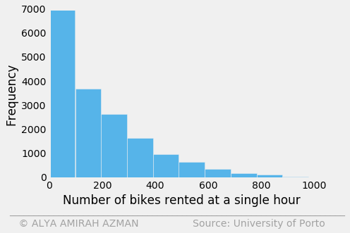

```python
%matplotlib inline

import matplotlib.style as style
import matplotlib.pyplot as plt

style.use('fivethirtyeight')

# color-blind friendly colors
colors = [[0,0,0], [230/255,159/255,0], [86/255,180/255,233/255], [0,158/255,115/255],
          [213/255,94/255,0], [0,114/255,178/255]]

# plot distribution of bike rentals from the dataframe
plt.hist(bike_rentals["cnt"], color=[86/255,180/255,233/255])
plt.grid(b=None)
plt.xlabel("Number of bikes rented at a single hour")
plt.ylabel("Frequency")
plt.text(x = -150, y = -1500,
    s = '____________________________________________________________________',
    color = 'grey', alpha = .7)

plt.text(x = -150, y = -2000,
    s = '   © ALYA AMIRAH AZMAN                 Source: University of Porto',
    fontsize = 14, color = 'grey', alpha = .7)
```

```python
# see correlation between the relavant columns to the number of bike rentals
bike_rentals.corr()["cnt"]
```

```
instant       0.278379
season        0.178056
yr            0.250495
mnth          0.120638
hr            0.394071
holiday      -0.030927
weekday       0.026900
workingday    0.030284
weathersit   -0.142426
temp          0.404772
atemp         0.400929
hum          -0.322911
windspeed     0.093234
casual        0.694564
registered    0.972151
cnt           1.000000
Name: cnt, dtype: float64
```

## Calculating Features

```python
def assign_label(hour):
    if hour >=0 and hour < 6:
        return 4
    elif hour >=6 and hour < 12:
        return 1
    elif hour >= 12 and hour < 18:
        return 2
    elif hour >= 18 and hour <=24:
        return 3

# reassign the hour labels to morning, afternoon, evening and night
bike_rentals["time_label"] = bike_rentals["hr"].apply(assign_label)

bike_rentals.head()
```

|  | instant | dteday | season | yr | mnth | hr | holiday | weekday | workingday | weathersit | temp | atemp | hum | windspeed | casual | registered | cnt | time_label |
| --- | --- | --- | --- | --- | --- | --- | --- | --- | --- | --- | --- | --- | --- | --- | --- | --- | --- | --- |
| 0 | 1 | 2011-01-01 | 1 | 0 | 1 | 0 | 0 | 6 | 0 | 1 | 0.24 | 0.2879 | 0.81 | 0.0 | 3 | 13 | 16 | 4 |
| 1 | 2 | 2011-01-01 | 1 | 0 | 1 | 1 | 0 | 6 | 0 | 1 | 0.22 | 0.2727 | 0.80 | 0.0 | 8 | 32 | 40 | 4 |
| 2 | 3 | 2011-01-01 | 1 | 0 | 1 | 2 | 0 | 6 | 0 | 1 | 0.22 | 0.2727 | 0.80 | 0.0 | 5 | 27 | 32 | 4 |
| 3 | 4 | 2011-01-01 | 1 | 0 | 1 | 3 | 0 | 6 | 0 | 1 | 0.24 | 0.2879 | 0.75 | 0.0 | 3 | 10 | 13 | 4 |
| 4 | 5 | 2011-01-01 | 1 | 0 | 1 | 4 | 0 | 6 | 0 | 1 | 0.24 | 0.2879 | 0.75 | 0.0 | 0 | 1 | 1 | 4 |

## Splitting the Data Into Train and Test Sets

```python
train = bike_rentals.sample(frac=0.8)
test = bike_rentals.loc[~bike_rentals.index.isin(train.index)]
```

## Applying Linear Regression

```python
from sklearn.linear_model import LinearRegression
import numpy as np

predictors = list(train.columns)

# exclude certain columns from the predictor columns
predictors.remove("cnt")
predictors.remove("casual")
predictors.remove("registered")
predictors.remove("dteday")

reg = LinearRegression()

# use Linear Regression to train machine learning algroithm on train
reg.fit(train[predictors], train["cnt"])

# make predictions using Linear Regression class on test
predictions = reg.predict(test[predictors])

# calculate the Mean Squared Error
np.mean((predictions - test["cnt"]) ** 2)
```

```
17158.582472156726
```

## Applying Decision Trees

```python
from sklearn.tree import DecisionTreeRegressor

reg = DecisionTreeRegressor()

# use Decision Tree Regressor to train machine learning algorithm on train
reg.fit(train[predictors], train["cnt"])

# make predictions using Decision Tree Regressor class on test
predictions = reg.predict(test[predictors])

# calculate the Mean Squared Error
np.mean((predictions - test["cnt"]) ** 2)
```

```
3364.9062140391256
```

```python
from sklearn.tree import DecisionTreeRegressor

reg = DecisionTreeRegressor(min_samples_leaf=5)

# use Decision Tree Regressor to train machine learning algorithm on train
reg.fit(train[predictors], train["cnt"])

# make predictions using Decision Tree Regressor class on test
predictions = reg.predict(test[predictors])

# calculate the Mean Squared Error
np.mean((predictions - test["cnt"]) ** 2)
```

```
2776.5708056772555
```

From applying Decision Trees, we note the lower mean squared error compared to applying Linear Regression. We also noted the reduced mean squared error after increasing the number of samples required to be at a leaf node ("min_samples_leaf") to 5.

# Applying Random Forests

```python
from sklearn.ensemble import RandomForestRegressor

reg = RandomForestRegressor()

# use Random Forest Regressor to fit random forest algorithm to train data
reg.fit(train[predictors], train["cnt"])

# make predictions using the Random Forest Regressor on test
predictions = reg.predict(test[predictors])

# calculate the Mean Squared Error
np.mean((predictions - test["cnt"]) ** 2)
```

```
2054.524660529344
```

```python
from sklearn.ensemble import RandomForestRegressor

reg = RandomForestRegressor(min_samples_leaf=5)

# use Random Forest Regressor to fit random forest algorithm to train data
reg.fit(train[predictors], train["cnt"])

# make predictions using the Random Forest Regressor on test
predictions = reg.predict(test[predictors])

# calculate the Mean Squared Error
np.mean((predictions - test["cnt"]) ** 2)
```

```
2222.255067461162
```

From applying Random Forests, we note the lower mean squared errors compared to applying Linear Regression and Decision Trees. However, increasing the number of samples required to be a leaf node ("min_samples_leaf") to 5 does not reduce the mean squared error.

## Next Steps

1) Calculate additional features, such as: An index combining temperature, humidity, and wind speed

2) Predict casual and registered instead of cnt.

# Conclusion

In this project, we predict the number of bikes rented in Washington D.C. in a give hour by different machine learning models.

By analyzing the results of each model, we noted that the Random Forest algorithm is the best model in our case as it gives us the lowest Mean Squared Error.